# Descriptive Statistics 1: Introduction to Statistics & Describing Data

We can vary the number of bins to get more or less detail from the histogram.

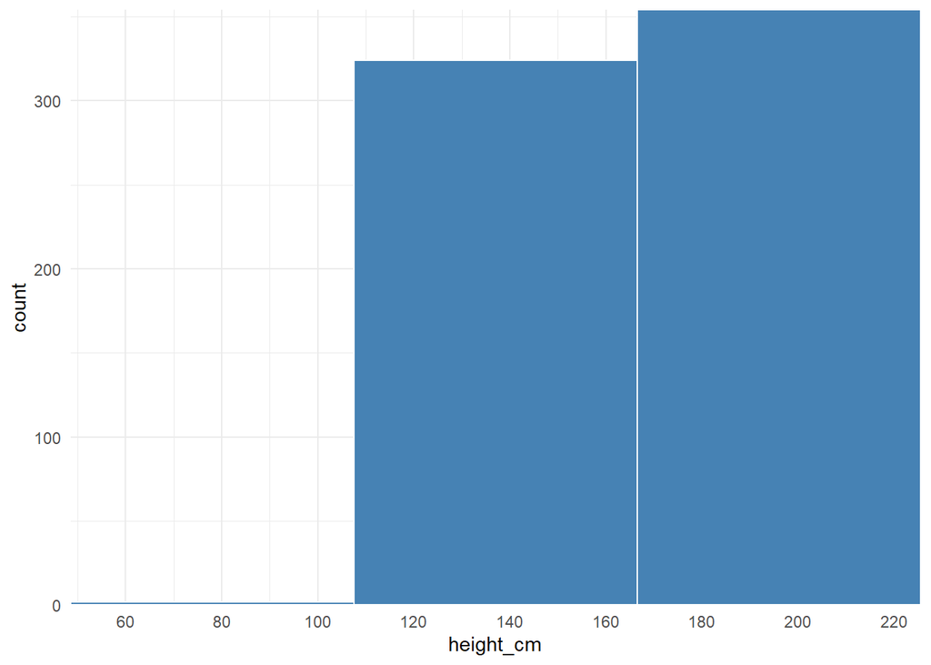

```r
# Try different numbers of bins

yao_adults_height +
  geom_histogram(
    bins = 3,
    color = "white",
    fill = "steelblue"
  )
```

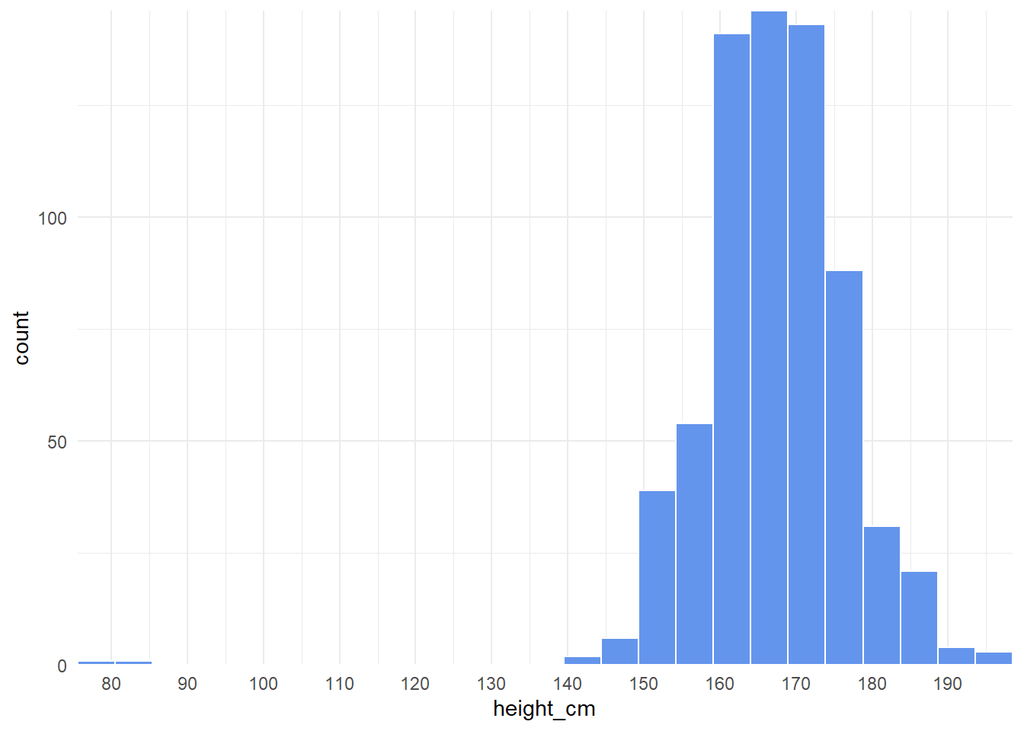

```r
yao_adults_height +
  geom_histogram(
    bins = 25,
    color = "white",
    fill = "cornflowerblue"
  )
```

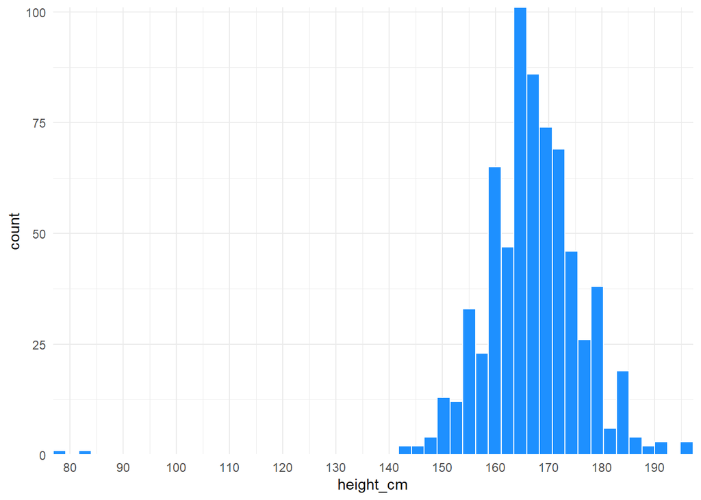

```r
yao_adults_height +
  geom_histogram(
    bins = 50,
    color = "white",
    fill = "dodgerblue"
  )
```

- By using smaller bins, we get a more accurate and precise estimate of how heights are distributed.

### Density Curves

- We can also represent continuous distributions with a smoothed curve, which is a useful alternative to the histogram.
- We can use a curve to approximate the histogram by plotting it on top of the bars.

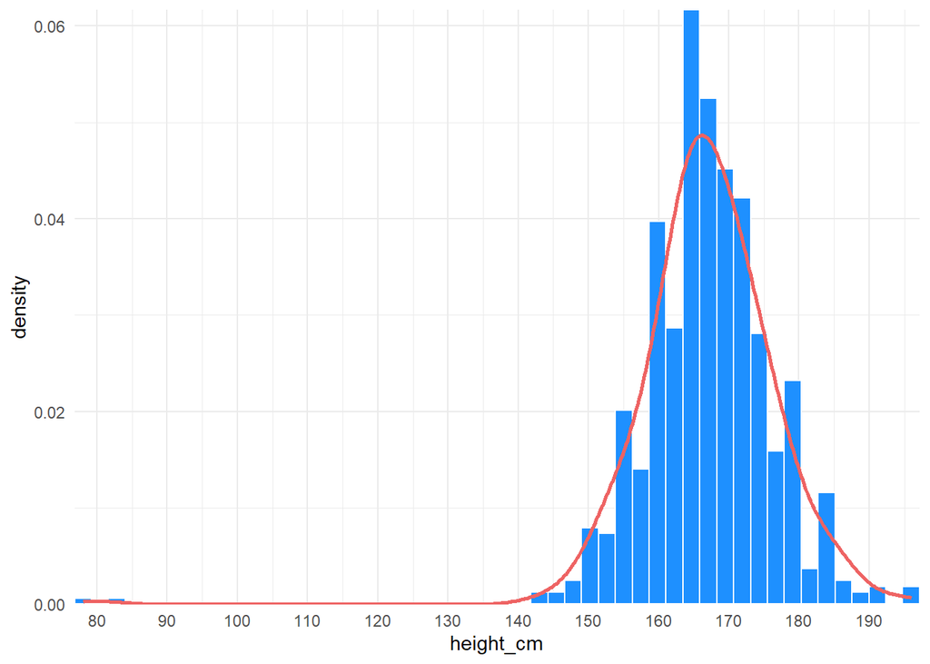

```r
yao_adults_height +
  geom_histogram(
    bins = 50,
    color = "white",
    fill = "dodgerblue",
    mapping = aes(y = after_stat(density))
  ) +
  geom_density(
    color = "indianred2",
    alpha = 0.25,
    linewidth = 1,
    bw = 3
  )
```

The curve tells us the same thing that the histogram tells us:

The curve has a few advantages over the histogram.

- For example, we don’t have any values in the second-last bin, but we can use the curve to calculate the probability.
- Furthermore, the curve is not limited by the width of the bins - we can use calculus to determine the probability of measuring someone between 172.5 and 183.7 cm, without having to round to the nearest bin size.
- Lastly, if we have very few measurements, we can still approximate a curve using the mean and standard deviation of the few data points that we have.

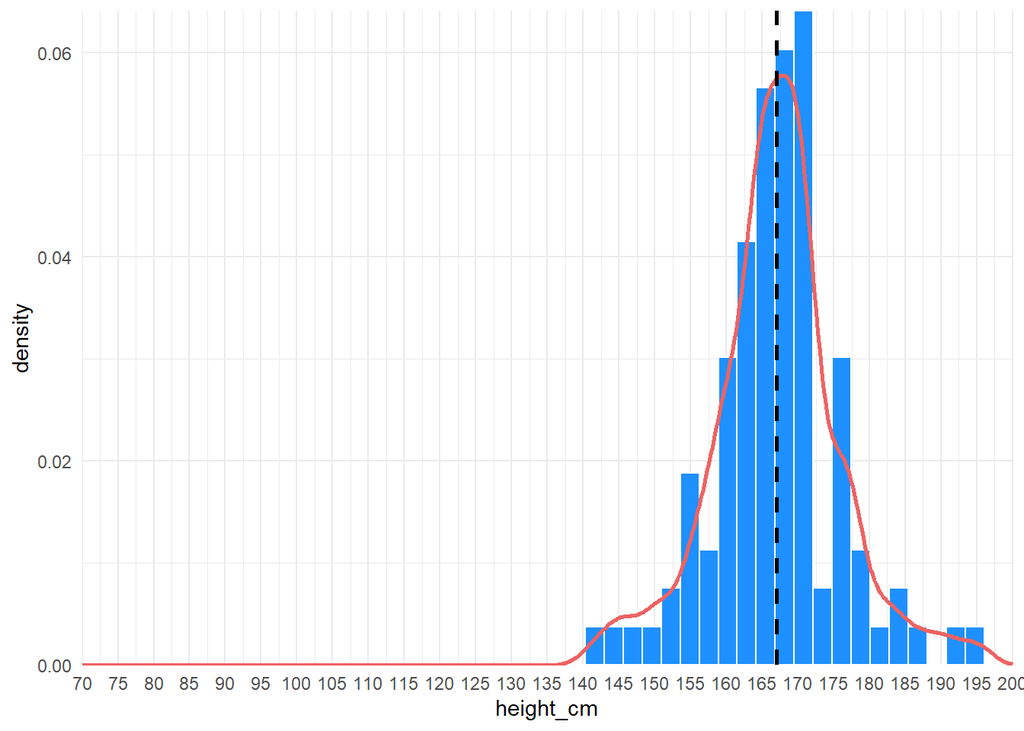

```r
ggplot(
  data = sample_n(yao_adults, 100),
  mapping = aes(x = height_cm)
) +
  geom_histogram(
    bins = 50,
    color = "white",
    fill = "dodgerblue",
    mapping = aes(y = after_stat(density))
  ) +
  geom_density(
    color = "indianred2",
    alpha = 0.25,
    linewidth = 1
  ) +
  scale_x_continuous(
    breaks = scales::pretty_breaks(n = 24),
    expand = c(0, 0), limits = c(70 , 200)
  ) +
  scale_y_continuous(expand = c(0, 0)) +
  geom_vline(aes(xintercept = mean(height_cm)),
    linetype = "dashed", linewidth = 1
  )
```

Try rerunning the code; each time will use a different random sample of 100 individuals from the dataset.

**TipStratifying kernel density plots**

The **`geom_density()`** function draws kernel density estimates, which is a smoothed version of a histogram. This is a useful alternative to the histogram for continuous data.

By plotting separate overlapping curves for each sex, we can graphically describe how the distribution of heights varies between sexes.

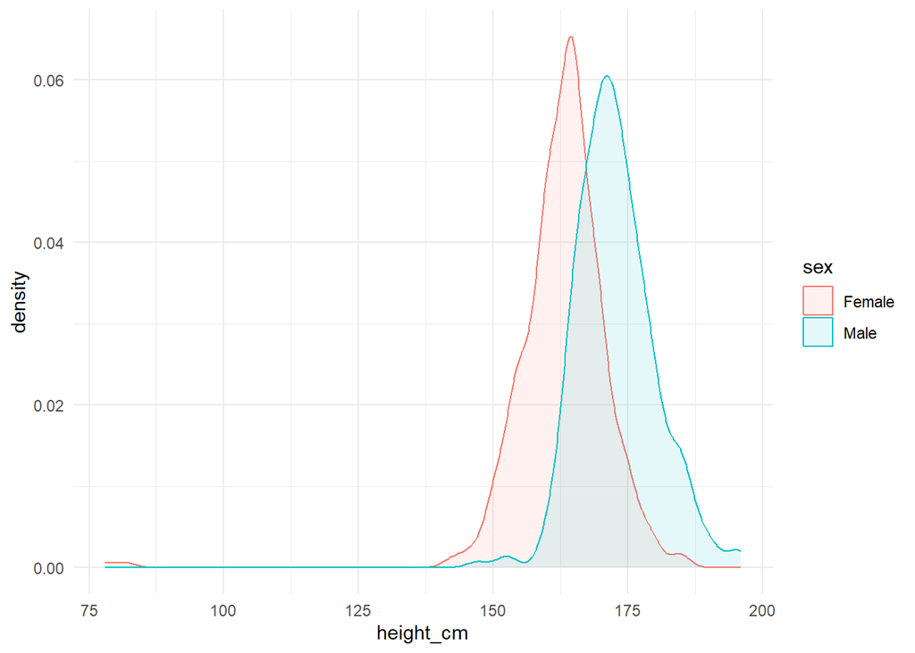

```r
ggplot(yao_adults, aes(height_cm,
  colour = sex,
  fill = sex
)) +
  geom_density(alpha = 0.1)
```

**NotePractice**

**Plotting Histograms**

- Plot a histogram showing the distribution of `n_bedridden_days` in `yaounde`.

Make notes on these key questions:

1. What are the smallest and largest values?
2. What are frequent and infrequent values?

**NotePractice**

**Density Plot of weight by sex**

- Plot a kernel density plot showing the distribution of weight for each sex in `yaounde`.
- Then make the same plot again using `yao_adults` instead of `yaounde`. Now that the children have been filtered out, do you notice any key differences?

Make notes on these key questions:

1. What is the “center” or “most typical” value for each sex? How similar are the distributions?
2. How do the values spread out? Is there a clear peak at the center? Are there multiple peaks?

### Boxplots

Let’s start with a simple boxplot by mapping one numeric variable from `yaounde`, the height of patients (**`height_cm`**).

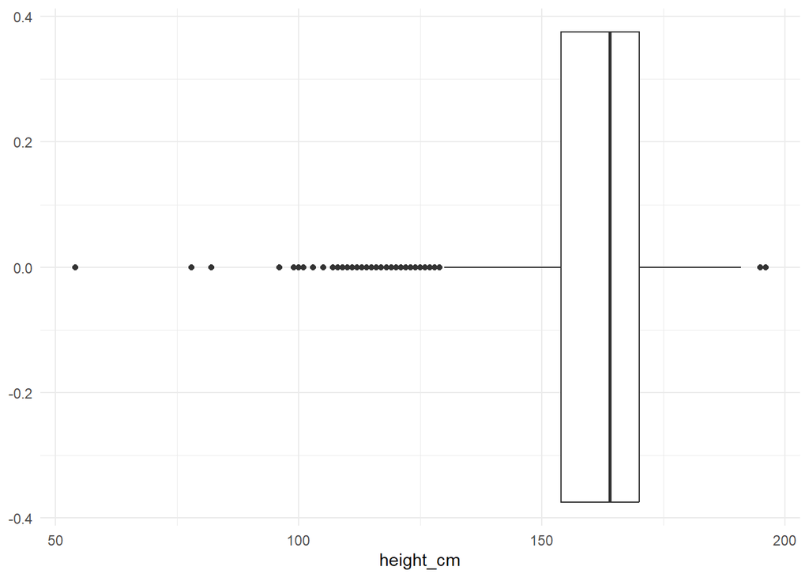

```r
# Simple boxplot of height_cm
ggplot(
  data = yaounde,
  mapping = aes(x = height_cm)
) +
  geom_boxplot()
```

A boxplot consists of two parts:

1. **Box** — Extends from the first to the third quartile (Q1 to Q3) with a line in the middle that represents the *median*. The range of values between Q1 and Q3 is also known as an *Interquartile range (IQR)*.
2. **Whiskers** — Lines extending from both ends of the box indicate variability outside Q1 and Q3. The minimum/maximum whisker values are calculated as $Q1 - 1.5 \times IQR$ to $Q3 + 1.5 \times IQR$ . Everything outside is represented as an *outlier* using dots or other markers.

**Tip**

The function for creating boxplots in {ggplot2} is **`geom_boxplot()`**. We can use `fill` argument inside the `aes()` function to color the boxes by a categorical variable.

To create a side-by-side boxplot (which is what we usually want), we need to add a categorical variable.

Let’s split `height_cm` by the **`sex`** variable.

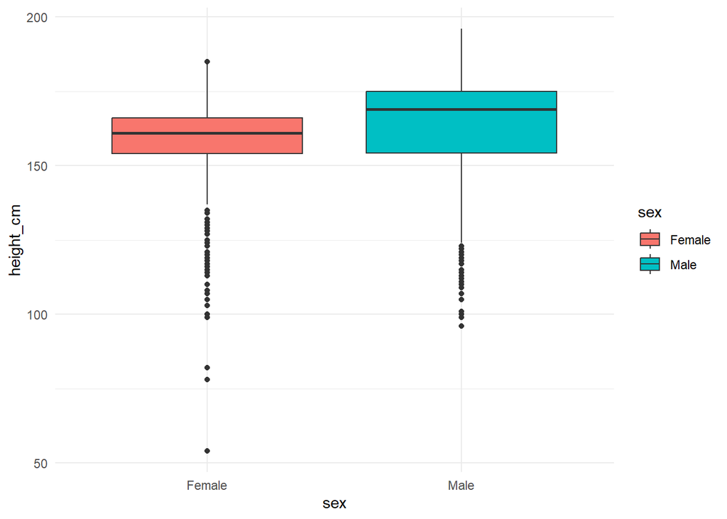

```r
ggplot(
  yaounde,
  aes(
    x = sex,
    y = height_cm,
    fill = sex
  )
) +
  geom_boxplot()
```

We can also use `coord_flip()` to swap the axes for a horizontal orientation:

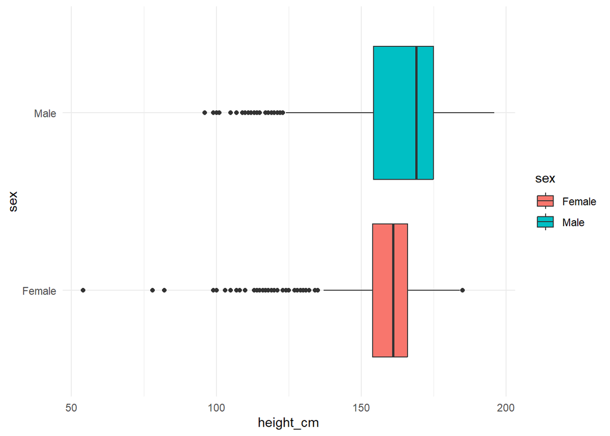

```r
ggplot(
  yaounde,
  aes(
    x = sex,
    y = height_cm,
    fill = sex
  )
) +
  geom_boxplot() +
  coord_flip()
```

We can clearly see that there are notable differences in median height (central line of each box) between sexes. However, there is a lot of overlap between the range of values.

Boxplots have the limitation that they summarize the data into just five numbers: the 1st quartile, the median (the 2nd quartile), the 3rd quartile, and the upper and lower whiskers. By doing this, we might miss important characteristics of the data.

One way to add more detail is to plot the individual observations as a **layer of points** on top of the boxplot with the **`geom_jitter()`** function.

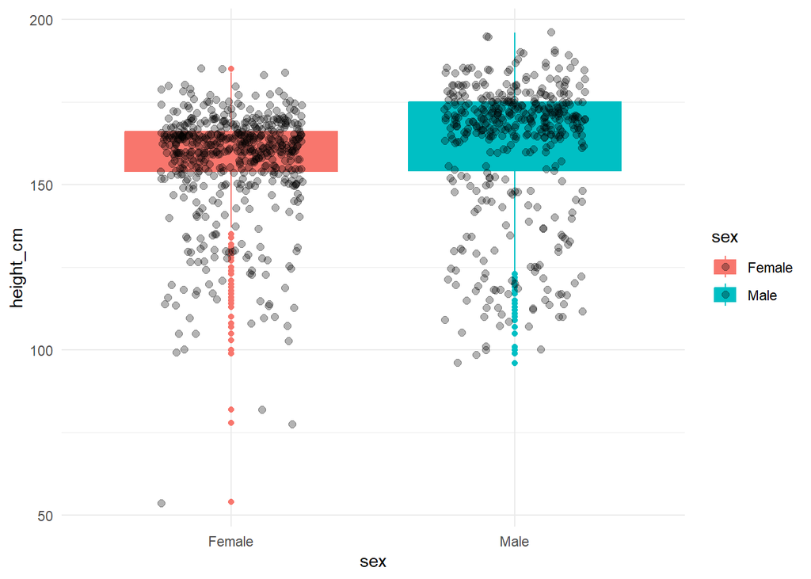

```r
ggplot(
  yaounde,
  aes(
    x = sex,
    y = height_cm,
    fill = sex
  )
) +
  geom_boxplot(aes(color = sex)) +
  geom_jitter(
    size = 2,
    width = 0.25,
    alpha = 0.3
  )
```

Here, additional patterns become visible, such as variations and potential outliers within each sex group.

You can try out different variations of stratifying boxplots. Here we use `facet_wrap()` to create side-by-side plots for each sex, with age category on the x-axis:

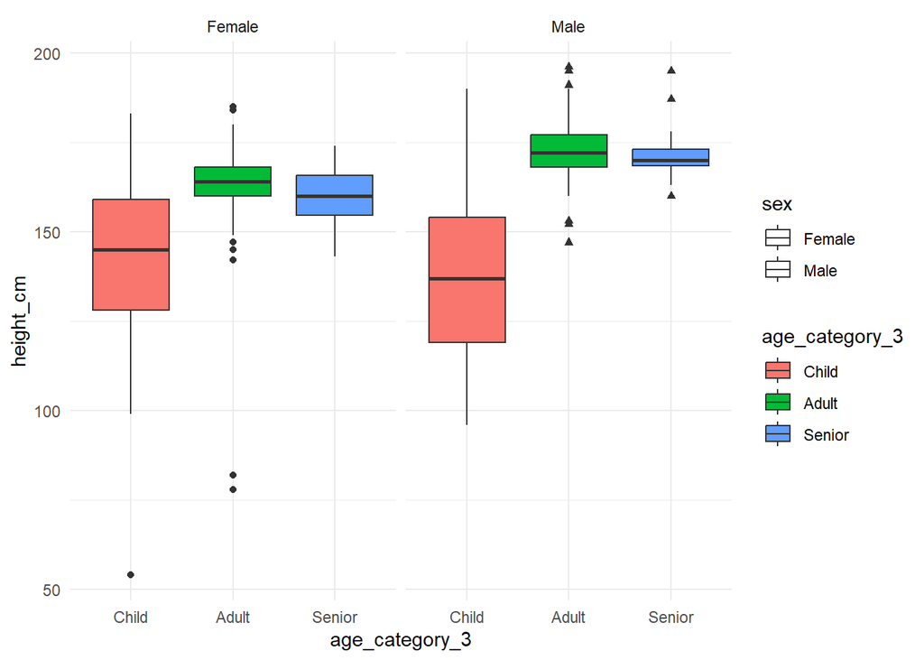

```r
# Comparing distributions across sub categories
ggplot(yaounde, aes(x = age_category_3, y = height_cm,
    fill = age_category_3,
    shape = sex)) +
  geom_boxplot() +
  facet_wrap(~sex)
```

In both panels, children show a much wider range of heights than adults and seniors - which makes sense, since children are still growing. Once people reach adulthood, height stabilizes, so the boxes for adults and seniors are much more compact. We can also see that adult males are taller than adult females on average. Interestingly, for children, the median height is similar between sexes (and actually slightly *lower* for male children in this sample).

### Violin Plots

An alternative to boxplots are **violin plots**. Similarly to how a density curve is an alternative to a histogram, a violin plot is like a density curve mirrored on both sides.

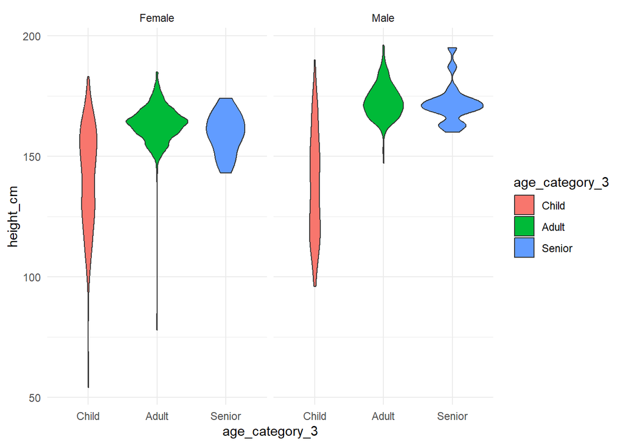

```r
# Density curve mirrored on the sides
ggplot(yaounde, aes(x = age_category_3, y = height_cm,
    fill = age_category_3,
    shape = sex)) +
  geom_violin() +
  facet_wrap(~sex)
```

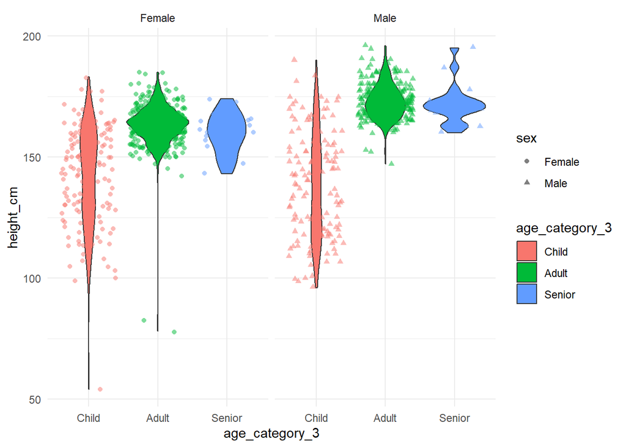

```r
# Add points to see individual observations
ggplot(yaounde, aes(x = age_category_3, y = height_cm,
    fill = age_category_3,
    shape = sex)) +
  geom_violin() +
  facet_wrap(~sex) +
  geom_jitter(alpha = 0.5, aes(color = age_category_3))
```

Overlaying the individual points makes it clear when small bumps or bulges in a violin are driven by just a handful of observations - a useful sanity check, since the smoothed curve can otherwise make small clusters of points look more substantial than they really are.

**TipAdding mean markers to a boxplot**

You may want to visualize the mean (average) value of the distributions on a boxplot.

We can do this by adding a statistics layer using the **`stat_summary()`** function.

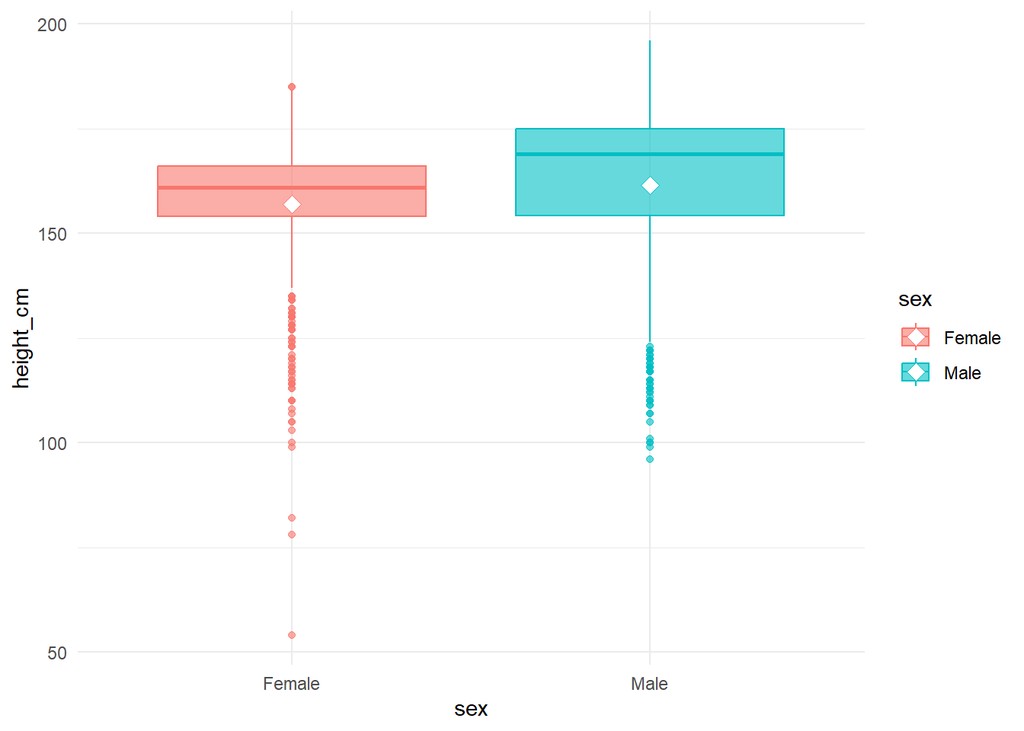

```r
# Add a marker to show the mean
ggplot(
  yaounde,
  aes(
    x = sex, height_cm,
    y = height_cm,
    fill = sex,
    color = sex
  )
) +
  geom_boxplot(alpha = 0.6) +
  stat_summary(
    fun = "mean",
    geom = "point",
    size = 3,
    shape = 23,
    fill = "white"
  )
```

**NotePractice**

**Plotting boxplots**

Create a boxplot showing the distribution of weights for each sex. Improve the plot by adding a layer of jittered points and a marker for the mean.

**NotePractice**

**Graphical methods for numeric variables**

We measured the age of 10,000 women in the UK. How would you suggest we look at the distribution of age across the sample population?

1. Produce a bar chart, with age across the x-axis and frequency on the y-axis
2. Produce a frequency table with all the ages in ascending order
3. Produce a histogram using age bins
4. Produce a bar chart, with age across the x-axis and gender across the y-axis

# Key Takeaways

- **Descriptive statistics** is the first step before any inferential analysis. It involves investigating variable types and their distributions.
- Variables are classified as **numerical** (continuous or discrete) or **categorical** (ordinal or nominal), and each type has appropriate graphical and numerical summaries.
- R data classes (`numeric`, `character`, `factor`, `logical`, `Date`) correspond to variable types, and it is important to convert variables to the correct class before analysis.
- **Graphical summaries** (histograms, density curves, boxplots, violin plots, bar charts) reveal patterns not always evident from numerical summaries alone.
- **Numerical summaries** (frequency tables, proportions) provide precise values for categorical distributions.

In the next lesson, we will continue our deep dive into numerical variables by covering **measures of central tendency** (mean, median, and mode) and how to calculate and interpret them in R.

# Answer Key

**Variable Types (Multiple-Choice)**

For each of the four variables below, state whether it is numerical or categorical. If the variable is categorical, specify if it’s ordinal or nominal. If numerical, classify as discrete or continuous.

1. Stress level, responses are “high”, “medium”, “low”. **Categorical – Ordinal**
2. Age in years. **Numerical – Discrete**
3. Height in centimeters. **Numerical – Continuous**
4. Country name. **Categorical – Nominal**

**Variable Types (Fill‑in‑the‑Blanks)**

Complete each sentence with the most appropriate term:

1. Quantitative variables are called **numeric**, whereas qualitative variables are called **categorical**.
2. Binary variables have exactly **two** categories.
3. **Nominal** categorical variables contain groups that cannot be meaningfully ordered.
4. Discrete numeric variables consist of whole numbers, also referred to as **integers**.
5. Long ordinal variables can often be treated as **continuous/numeric**, if they have sufficient categories and are relatively evenly distributed.

**Identifying Variable Types and R Data Classes**

1. `age` – **Numerical (Discrete), R class: Numeric**
2. `highest_education` – **Categorical (Ordinal), R class: Character or Factor**
3. `is_smoker` – **Categorical (Nominal), R class: Character**
4. `date_surveyed` – **Date, R class: Date**
5. `weight_kg` – **Numerical (Continuous), R class: Numeric**
6. `igg_result` – **Categorical (Nominal), R class: Character**

R data classes correspond to different variable types:

| Variable Type | R Data Class | Example Variables in Yaounde Dataset |
| --- | --- | --- |
| Continuous | Numeric | `height_cm`, `weight_kg` |
| Discrete | Integer, Numeric | `age`, `n_days_miss_work` |
| Ordinal | Factor (ordered) | `highest_education` |
| Nominal | Factor, Character | `sex`, `neighborhood` |
| Logical | Logical | `is_pregnant`, `is_medicated` |
| Date | Date | `date_surveyed` |

**Reordering the `age_category` variable**

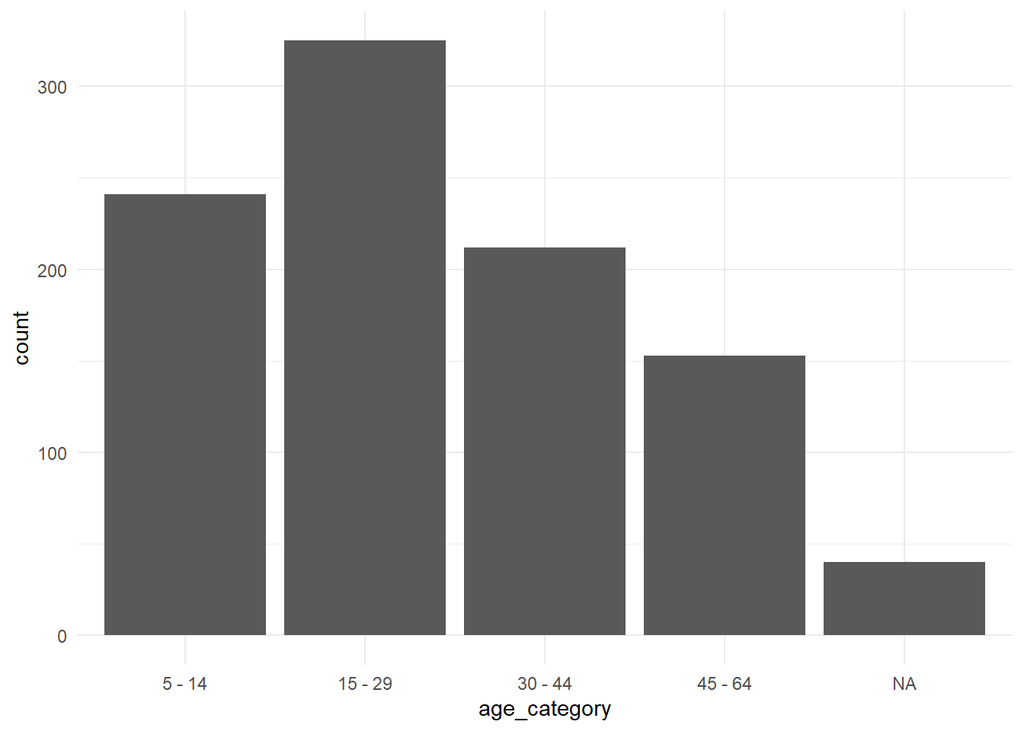

```r
yaounde <- yaounde %>%
  mutate(
    age_category = factor(age_category,
      levels = c("5 - 14", "15 - 29", "30 - 44", "45 - 64", "65+")
    )
  )

ggplot(yaounde) +
  geom_bar(aes(x = age_category))
```

**Frequency Tables**

Use the `tabyl()` function from the `{janitor}` package to answer the following:

1. Create a frequency table of `has_contact_covid`.

```r
yaounde %>% tabyl(has_contact_covid)
```

```
          has_contact_covid   n    percent
           No COVID contact 705 0.72605561
       Recent COVID contact  35 0.03604531
 Unsure about COVID contact 231 0.23789907
```

2. Create a two-way frequency table between `has_contact_covid` and `igg_result`.

```r
yaounde %>% tabyl(
  has_contact_covid,
  igg_result
)
```

```
          has_contact_covid Negative Positive
           No COVID contact      502      203
       Recent COVID contact       19       16
 Unsure about COVID contact      148       83
```

3. Use `adorn_percentages("row")` to display row-wise proportions in the table created above.

```r
yaounde %>%
  tabyl(
    has_contact_covid,
    igg_result
  ) %>%
  adorn_percentages("row")
```

```
          has_contact_covid  Negative  Positive
           No COVID contact 0.7120567 0.2879433
       Recent COVID contact 0.5428571 0.4571429
 Unsure about COVID contact 0.6406926 0.3593074
```

**Bar Charts**

Use `ggplot()` to create the following charts:

1. Plot a bar chart showing the distribution of `age_category_3`, colored by `igg_result`.

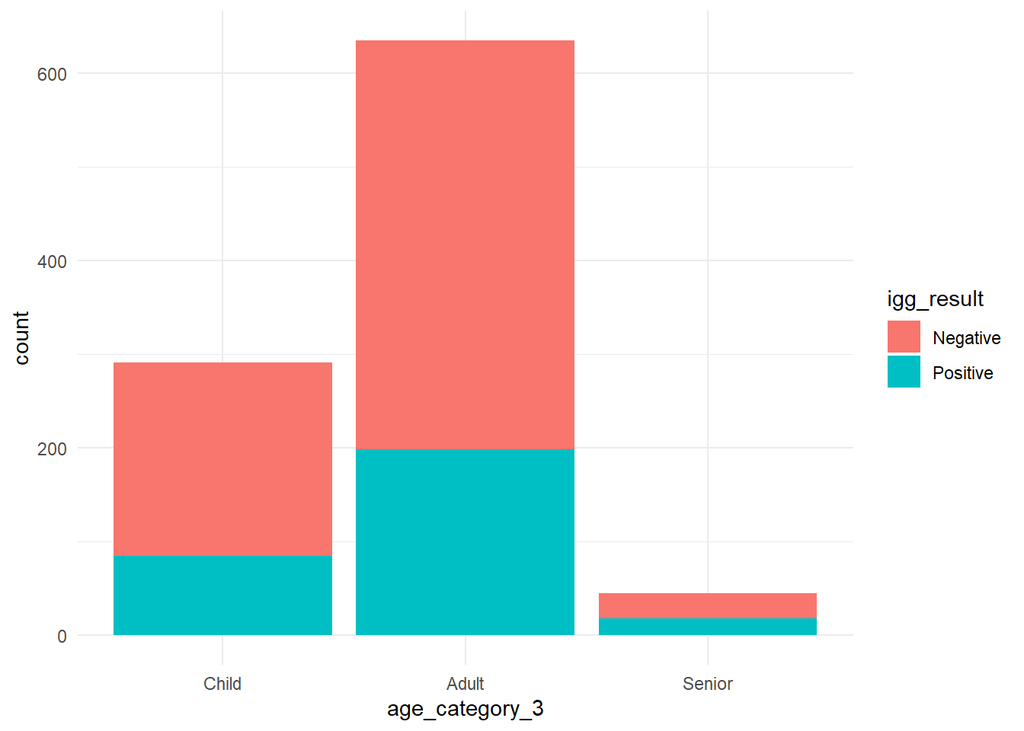

```r
ggplot(yaounde) +
  geom_bar(aes(x = age_category_3, fill = igg_result))
```

2. Create a percent-stacked bar chart showing the same variables.

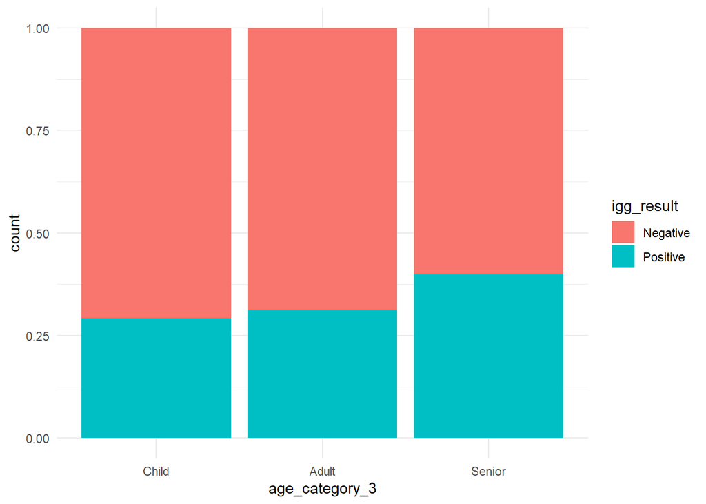

```r
ggplot(yaounde) +
  geom_bar(aes(x = age_category_3, fill = igg_result),
    position = "fill"
  )
```

3. Add text labels to show the count of individuals in each age group, using `geom_text()`. Customize the look of the plot as desired (titles, labels, and colors).

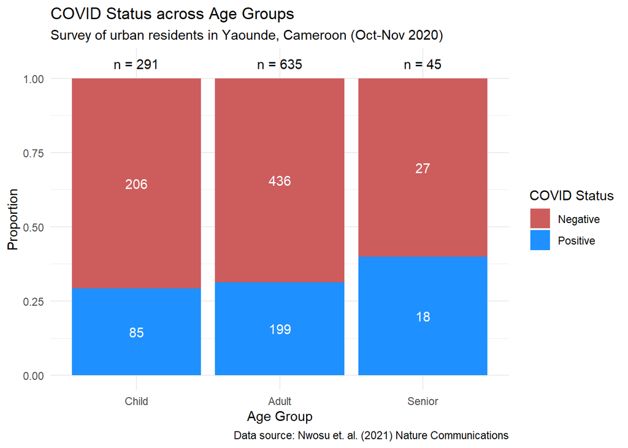

```r
ggplot(yaounde) +
  geom_bar(
    aes(
      x = age_category_3,
      fill = igg_result
    ),
    position = "fill"
  ) +
  geom_text(
    aes(x = age_category_3, label = after_stat(count), group = igg_result),
    stat = "count",
    position = position_fill(vjust = 0.5),
    color = "white"
  )  +
  geom_text(
    aes(x = age_category_3, label = paste("n =", after_stat(count))),
    stat = "count",
    position = position_fill(vjust = 1.05)
  ) +
  labs(x = "Age Group", y = "Proportion", fill  = "COVID Status",
    title = "COVID Status across Age Groups",
    subtitle = "Survey of urban residents in Yaounde, Cameroon (Oct-Nov 2020)",
    caption = "Data source: Nwosu et. al. (2021) Nature Communications"
  ) +
  scale_fill_manual(
    values = c("Negative" = "indianred", "Positive" = "dodgerblue")) +
  theme_minimal() +
  scale_y_continuous(expand = c(0,0.05))
```

**Histograms**

- Plot a histogram showing the distribution of `n_bedridden_days` in `yaounde`.

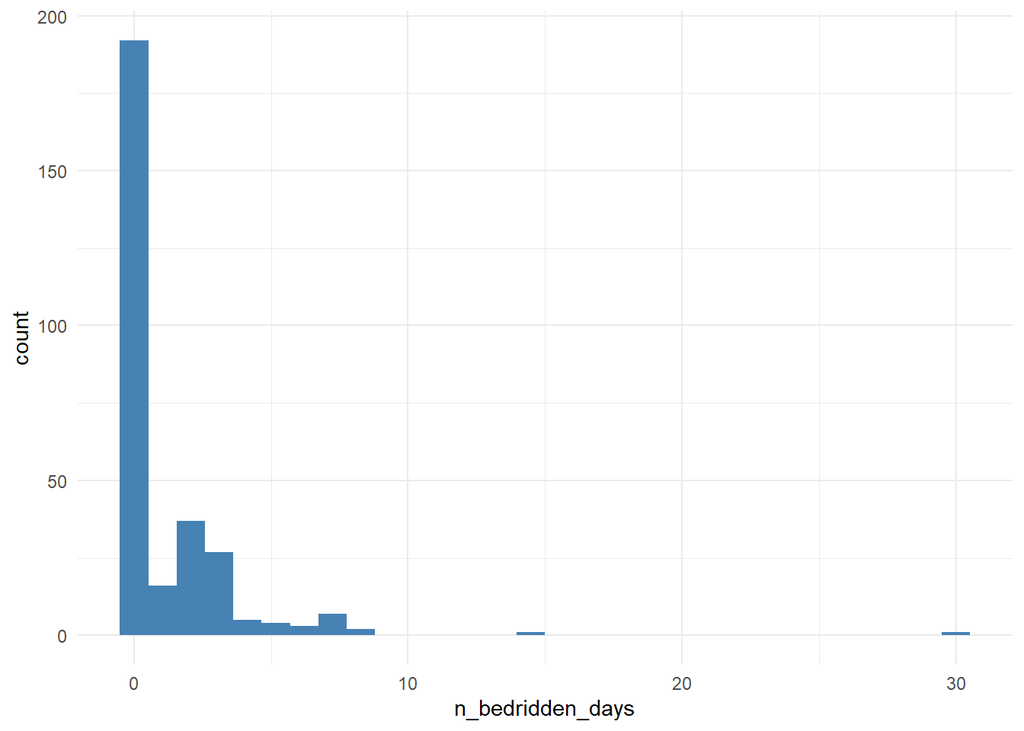

```r
ggplot(
  data = yaounde,
  mapping = aes(x = n_bedridden_days)
) +
  geom_histogram(fill = "steelblue")
```

**Density Plot: weight by sex**

- Plot a kernel density plot showing the distribution of weight for each sex in `yaounde`.

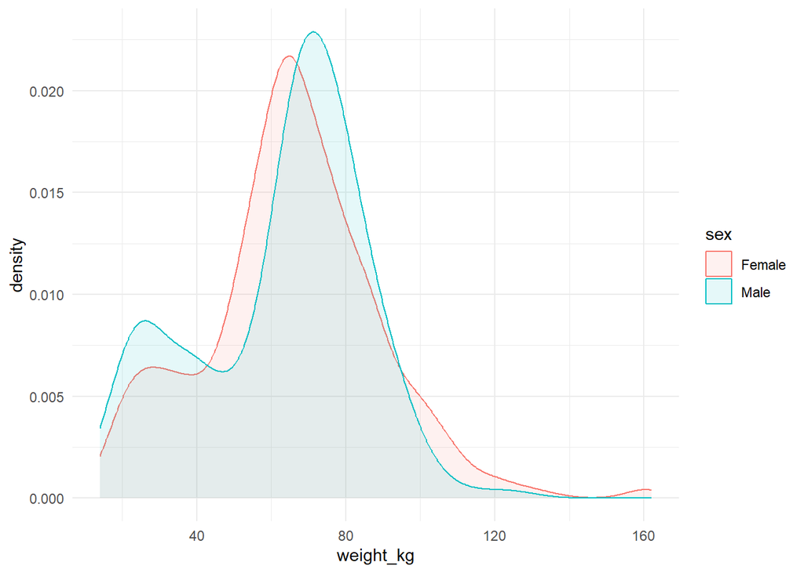

```r
ggplot(yaounde, aes(weight_kg,
  colour = sex,
  fill = sex
)) +
  geom_density(alpha = 0.1)
```

Using `yao_adults`:

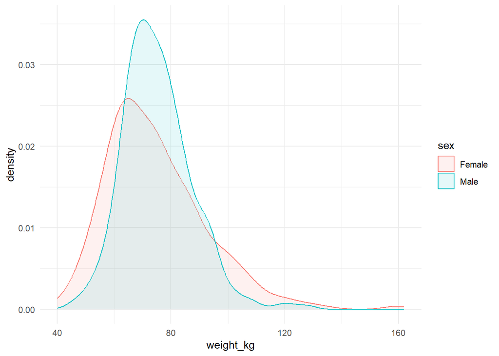

```r
ggplot(yao_adults, aes(weight_kg,
  colour = sex,
  fill = sex
)) +
  geom_density(alpha = 0.1)
```

- Shows typical weight slightly differs by sex.
- Distributions largely overlap.
- In `yaounde` (with children): distribution is bimodal - with two peaks. Perhaps one for children and one for adults.
- In `yao_adults` (without children): distribution becomes unimodal with a single clear peak.
- Males have a slightly higher central tendency.

**Boxplots**

- Create a boxplot showing the distribution of weights for each sex. Improve the plot by adding a layer of jittered points and a marker for the mean.

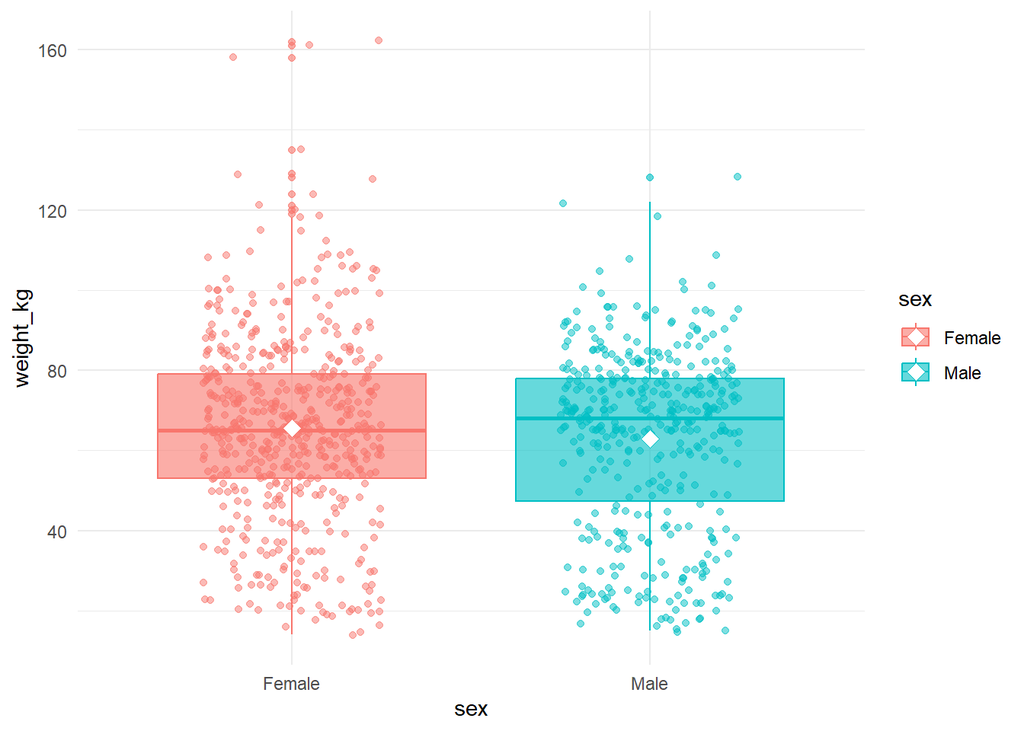

```r
ggplot(
  yaounde,
  aes(
    x = sex,
    y = weight_kg,
    fill = sex,
    color = sex
  )
) +
  geom_boxplot(alpha = 0.6) +
  geom_jitter(width = 0.25, alpha = 0.5) +
  stat_summary(
    fun = "mean",
    geom = "point",
    size = 3,
    shape = 23,
    fill = "white"
  )
```

**Graphical methods for numeric variables**

We measured the age of 10,000 women in the UK. How would you suggest we look at the distribution of age across the sample population?

1. Produce a bar chart, with age across the x-axis and frequency on the y-axis
2. Produce a frequency table with all the ages in ascending order
3. **Produce a histogram using age bins**
4. Produce a bar chart, with age across the x-axis and gender across the y-axis

# Appendix: R functions used in this lesson

- **Data Import & Setup**
  - **`read_csv()`**  
    Reads CSV files into a data frame (from the **readr** package).
  - **`here()`**  
    Constructs file paths relative to the project’s root (from the **here** package).
- **Data Exploration & Inspection**
  - **`spec()`**  
    Retrieves the full column specification of a data frame (from **readr**).
  - **`str()`**  
    Displays the structure of a data frame in a compact format (base R).
  - **`glimpse()`**  
    Displays the structure of a data frame in a tidyverse-friendly format (from **dplyr**/**tibble**).
  - **`head()`**  
    Shows the first few rows of a data frame.
  - **`vis_dat()`**  
    Visualizes the data types of each variable in a data frame (from the **visdat** package).
  - **`inspect_cat()`**  
    Summarizes categorical variables in a data frame (from the **inspectdf** package).
  - **`inspect_num()`**  
    Summarizes numeric variables in a data frame (from the **inspectdf** package).
  - **`inspect_types()`**  
    Summarizes the count of each data type in a data frame (from the **inspectdf** package).
  - **`show_plot()`**  
    Displays a visual summary of inspected data (from the **inspectdf** package).
- **Data Manipulation & Summary**
  - **`%>%`**  
    The pipe operator for chaining operations (from **magrittr** or **dplyr**).
  - **`mutate()`**  
    Creates or transforms variables in a data frame (from **dplyr**).
  - **`across()`**  
    Applies a function across multiple columns (from **dplyr**).
  - **`filter()`**  
    Subsets rows based on conditions (from **dplyr**).
  - **`factor()`**  
    Converts a variable to a factor with specified levels (base R).
  - **`as.logical()`**  
    Converts a variable to logical type (base R).
  - **`as.integer()`**  
    Converts a variable to integer type (base R).
  - **`tabyl()`**  
    Creates frequency tables, showing counts (and can compute percentages) for categorical variables (from the **janitor** package).
  - **`adorn_percentages()`**  
    Adds percentage calculations to frequency tables (from the **janitor** package).
- **Data Visualization (using ggplot2)**
  - **`ggplot()`**  
    Initializes a ggplot object.
  - **`aes()`**  
    Sets up aesthetic mappings in ggplot2 plots.
  - **`geom_bar()`**  
    Creates bar charts.
  - **`geom_histogram()`**  
    Creates histograms.
  - **`geom_density()`**  
    Creates kernel density plots.
  - **`geom_boxplot()`**  
    Creates boxplots.
  - **`geom_violin()`**  
    Creates violin plots.
  - **`geom_jitter()`**  
    Adds jittered points to a plot to show individual observations.
  - **`geom_text()`**  
    Adds text labels to a plot.
  - **`stat_summary()`**  
    Adds summary statistics (e.g., mean markers) as a layer in a plot.
  - **`facet_wrap()`**  
    Creates small multiples, splitting a plot by a categorical variable.
  - **`coord_flip()`**  
    Swaps the x and y axes of a plot.
  - **`scale_fill_manual()`**  
    Manually sets fill colors for aesthetic mappings.

# Contributors

The following team members contributed to this lesson:

- [JOY VAZ](https://thegraphcourses.org/members/joy)  
  R Instructor and Mathematical Modeller, The GRAPH Network

  Loves doing science and teaching science
- [KENE DAVID NWOSU](https://thegraphcourses.org/members/kendavidn/)  
  Data analyst, The GRAPH Network

  Passionate about world improvement

# References

Some material in this lesson was adapted from the following sources:

- Irizarry, Rafael A. 2019. *Introduction to Data Science: Statistics and Prediction Algorithms Through Case Studies*. https://rafalab.dfci.harvard.edu/dsbook-part-2/.
- Cannell, Brad, and Melvin Livingston. n.d. *R for Epidemiology*. https://www.r4epi.com/.
- GeeksforGeeks. 2025. “Introduction of Statistics and Its Types.” https://www.geeksforgeeks.org/introduction-of-statistics-and-its-types/.
- Starmer, Josh. *StatQuest with Josh Starmer* [YouTube Channel]. https://www.youtube.com/channel/UCtYLUTtgS3k1Fg4y5tAhLbw.
- The GRAPH Courses. *FoSSA: Fundamentals of Statistical Software & Analysis*. https://thegraphcourses.org/courses/fossa/.
- University of Miami Libraries. *Introduction to Data Analysis and R*. https://www.library.miami.edu/data-services/data-analysis.html.
- Sullivan, G. M., & Artino, A. R., Jr (2013). Analyzing and interpreting data from likert-type scales. *Journal of graduate medical education*, *5*(4), 541–542. https://doi.org/10.4300/JGME-5-4-18
- Wickham, H. et al. *R for Data Science (2e)*. https://r4ds.hadley.nz/.
- University of Florida. *R Data Classes*. https://users.phhp.ufl.edu/rlp176/Courses/PHC6089/R_notes/DataClasses.html.

This work is licensed under the [Creative Commons Attribution Share Alike](https://creativecommons.org/licenses/by-sa/4.0/) license.